# Project: No-Show Appointments Analysis

- Introduction
- Data Wrangling
- Exploratory Data Analysis
- Conclusions
- Limitation

## Introduction

> The No-Show Appointments dataset includes more than 110 thousands recoreds of medical appointments in Brazil. These medical appointments recoreds are collected form 62 thousands patients, which means that the patient could have more than one medical appointment recored. This dataset is focused on the question of whether the patients are going to show up for their appointment or not. Since this is the focused of the dataset, the dependent variable will be the column which represents whether the patients showed up or not

```python
# We have to import the libraries

import pandas as pd
import numpy as np
import matplotlib.pyplot as plt
%matplotlib inline
import datetime as dt
```

## Data Wrangling

### General Properties

```python
# Reading the dataset

app = pd.read_csv('Input/noshowappointments-kagglev2-may-2016.csv')
print (app.shape)
app.head(2)
```

```
(110527, 14)
```

|  | PatientId | AppointmentID | Gender | ScheduledDay | AppointmentDay | Age | Neighbourhood | Scholarship | Hipertension | Diabetes | Alcoholism | Handcap | SMS_received | No-show |
| --- | --- | --- | --- | --- | --- | --- | --- | --- | --- | --- | --- | --- | --- | --- |
| 0 | 2.987250e+13 | 5642903 | F | 2016-04-29T18:38:08Z | 2016-04-29T00:00:00Z | 62 | JARDIM DA PENHA | 0 | 1 | 0 | 0 | 0 | 0 | No |
| 1 | 5.589980e+14 | 5642503 | M | 2016-04-29T16:08:27Z | 2016-04-29T00:00:00Z | 56 | JARDIM DA PENHA | 0 | 0 | 0 | 0 | 0 | 0 | No |

```python
# There is no missing value, which is a good thing
# However,ScheduledDay and AppointmentDay should be stored as datetime. We will fix that in Data Cleaning sectoin
app.info()
```

```
<class 'pandas.core.frame.DataFrame'>
RangeIndex: 110527 entries, 0 to 110526
Data columns (total 14 columns):
 #   Column          Non-Null Count   Dtype
---  ------          --------------   -----
 0   PatientId       110527 non-null  float64
 1   AppointmentID   110527 non-null  int64
 2   Gender          110527 non-null  object
 3   ScheduledDay    110527 non-null  object
 4   AppointmentDay  110527 non-null  object
 5   Age             110527 non-null  int64
 6   Neighbourhood   110527 non-null  object
 7   Scholarship     110527 non-null  int64
 8   Hipertension    110527 non-null  int64
 9   Diabetes        110527 non-null  int64
 10  Alcoholism      110527 non-null  int64
 11  Handcap         110527 non-null  int64
 12  SMS_received    110527 non-null  int64
 13  No-show         110527 non-null  object
dtypes: float64(1), int64(8), object(5)
memory usage: 11.8+ MB
```

```python
# There is not any duplicated rows, which is a good thing as well

app.duplicated().sum()
```

```
0
```

```python
# From the describe function, We can notice the minimum value of Age is negative. Age can not be negative
# We will fix that in Data Cleaning sectoin

app.describe()
```

|  | PatientId | AppointmentID | Age | Scholarship | Hipertension | Diabetes | Alcoholism | Handcap | SMS_received |
| --- | --- | --- | --- | --- | --- | --- | --- | --- | --- |
| count | 1.105270e+05 | 1.105270e+05 | 110527.000000 | 110527.000000 | 110527.000000 | 110527.000000 | 110527.000000 | 110527.000000 | 110527.000000 |
| mean | 1.474963e+14 | 5.675305e+06 | 37.088874 | 0.098266 | 0.197246 | 0.071865 | 0.030400 | 0.022248 | 0.321026 |
| std | 2.560949e+14 | 7.129575e+04 | 23.110205 | 0.297675 | 0.397921 | 0.258265 | 0.171686 | 0.161543 | 0.466873 |
| min | 3.920000e+04 | 5.030230e+06 | -1.000000 | 0.000000 | 0.000000 | 0.000000 | 0.000000 | 0.000000 | 0.000000 |
| 25% | 4.172615e+12 | 5.640286e+06 | 18.000000 | 0.000000 | 0.000000 | 0.000000 | 0.000000 | 0.000000 | 0.000000 |
| 50% | 3.173180e+13 | 5.680573e+06 | 37.000000 | 0.000000 | 0.000000 | 0.000000 | 0.000000 | 0.000000 | 0.000000 |
| 75% | 9.439170e+13 | 5.725524e+06 | 55.000000 | 0.000000 | 0.000000 | 0.000000 | 0.000000 | 0.000000 | 1.000000 |
| max | 9.999820e+14 | 5.790484e+06 | 115.000000 | 1.000000 | 1.000000 | 1.000000 | 1.000000 | 4.000000 | 1.000000 |

```python
# We do not need these columns. Therefore, we will drop them
app.drop(columns = ['PatientId','AppointmentID','Handcap'],inplace=True)
```

### Fixing the data type of ScheduledDay and AppointmentDay columns

```python
# To convert ScheduledDay and AppointmentDay to datetime

app['ScheduledDay'] = pd.to_datetime(app['ScheduledDay'], format='%Y/%m/%d')
app['AppointmentDay'] = pd.to_datetime(app['AppointmentDay'], format='%Y/%m/%d')
```

```python
# We need to convert No-show column to intger since it will be easier for us to use.
# Also, I have change the encoding of the No-show column: when it says 1, it menas
# the patient showed up to their appointments, and when it says 0, it means the patient did not show up

app['Show_up'] = np.where((app['No-show'] == 'No'), 1,
                             np.where((app['No-show']== 'Yes'), 0, 5))
print (app['Show_up'].dtype)
app['Show_up'].value_counts()
```

```
int32
```

```
1    88208
0    22319
Name: Show_up, dtype: int64
```

```python
# We are going to delete the No_show column since we replaced by Show_up column
del app['No-show']
```

### Removing Inaccurate Data

> The ScheduledDay must come before AppointmentDay. Therefore, I am creating a new column to calculate the difference days between ScheduledDay and AppointmentDay. If the days postive, it means that the AppointmentDay come before the ScheduledDay, which it seems to be wrong data.

```python
app['Difference_days'] = (app['ScheduledDay'] - app['AppointmentDay']).dt.days
```

```python
# We have Five recoreds, which the AppointmentDay comes before ScheduledDay
print (app[app['Difference_days']>0].shape)

# We are going to exclude these recoreds since it seems to be incorrect data.
print (app.shape)
app = app[app['Difference_days']<=0]
print (app.shape)
```

```
(5, 12)
(110527, 12)
(110522, 12)
```

```python
# We have only one recored, which the Age is less than then Zero
# Age can not be negative. We have some records have age as zero,but we will keep them since it might be infant patients
print (app[app['Age']<0].shape)

# We are going to exclude these recoreds since it seems to be incorrect data.
print (app.shape)
app = app[app['Age']>=0]
print (app.shape)
```

```
(1, 12)
(110522, 12)
(110521, 12)
```

## Exploratory Data Analysis

Here are some basic points, which we can conclude from the charts shown below.

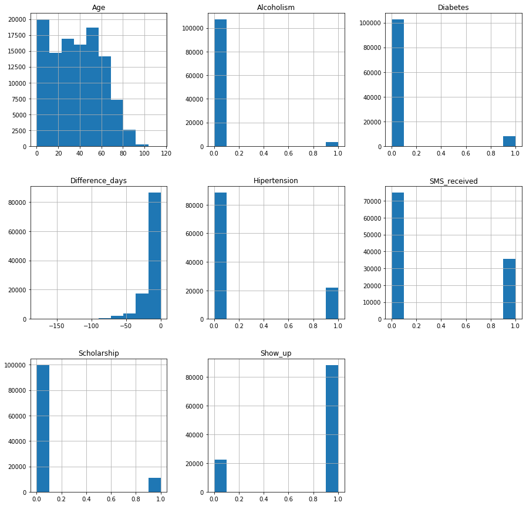

```python
# Histogram charts for the whole dataset in order to take an overview of the date

app.hist(figsize=(15,15));
```

#### Since our dependent variable is the column, which represents whether the patients are showing up or not for their appointment, we will create masks for that column

```python
# Masks for the dependent variable

Showed_yes = app.Show_up == True
Showed_no = app.Show_up == False
```

# Question 1

## Do people take care of themselves when they get older?

## As we can notice in the histogram chart below, the number of patients who do not show up for their appointments decrease as the age of patients increase.

#### Hence, we can conclude that the older people will most likely show up for their appointments

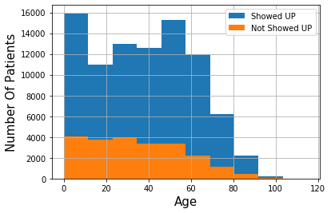

```python
# Histogram chart
app.Age[Showed_yes].hist(label= 'Showed UP')
app.Age[Showed_no].hist(label= 'Not Showed UP')
plt.xlabel('Age', fontsize=15)
plt.ylabel('Number Of Patients', fontsize=15)
plt.legend();
```

### Another way of displaying the chart

```python
# Created new column, which categorized patients based on their ages into five groups in order to graph them esaily

app['Age_group'] = np.where((app['Age'] >= 0)&(app['Age']<=20), '0-20',
                    np.where((app['Age'] > 20)&(app['Age']<=40), '21-40',
                     np.where((app['Age'] > 40)&(app['Age']<=60), '41-60',
                      np.where((app['Age'] > 60)&(app['Age']<=80), '61-80',
                        np.where((app['Age']>80), 'Above 80', 'N/A')))))

app['Age_group'].value_counts()
```

```
0-20        31846
41-60       30081
21-40       28833
61-80       16910
Above 80     2851
Name: Age_group, dtype: int64
```

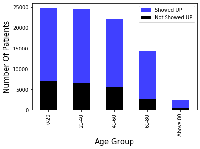

```python
app.Age_group[Showed_yes].value_counts().plot(kind='bar', alpha=0.75,color='blue', label='Showed UP')
app.Age_group[Showed_no].value_counts().plot(kind='bar',color='black', label='Not Showed UP')
plt.xlabel('Age Group', fontsize=15)
plt.ylabel('Number Of Patients', fontsize=15)
plt.legend();
```

```python
# Here are the mean of Age column for both patients who are showing up and not showing up.

print (app.Age[Showed_yes].mean(),',', app.Age[Showed_no].mean())

# the mean of Age column of showing up patients are larger than the the mean of Age column for not showing up patients.
```

```
37.790504154999034 , 34.31787218786412
```

# Question 2

## Having Diabetes or Hypertension will force you to not skip the medical appointment?

## As we can notice in the two histogram charts below, patients who have diabetes or hypertension are less likely to skip the medical appointment.

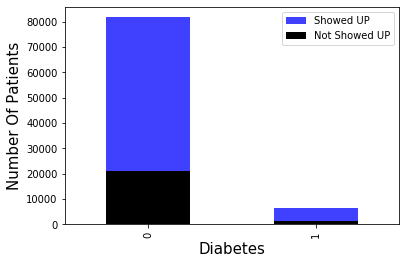

```python
# Diabetes chart

app.Diabetes[Showed_yes].value_counts().plot(kind='bar',alpha=0.75, color='blue', label='Showed UP')
app.Diabetes[Showed_no].value_counts().plot(kind='bar',color='black', label='Not Showed UP')
plt.xlabel('Diabetes', fontsize=15)
plt.ylabel('Number Of Patients', fontsize=15)
plt.legend();
```

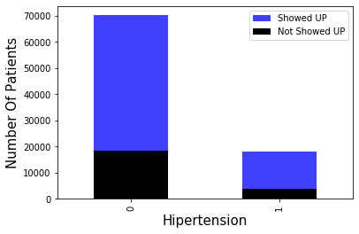

```python
# Hipertension chart

app.Hipertension[Showed_yes].value_counts().plot(kind='bar',alpha=0.75, color='blue', label='Showed UP')
app.Hipertension[Showed_no].value_counts().plot(kind='bar', color='black', label='Not Showed UP')
plt.xlabel('Hipertension', fontsize=15)
plt.ylabel('Number Of Patients', fontsize=15)
plt.legend();
```

## Conclusions

> In conclusion, the No-Show Appointments dataset was almost cleaned. I only have found few inaccurate data, such as inaccurate type of data, negative value in age column, and some recored have the Appointment Day came before the Scheduled Day, which seems to be wrong data. All of these inaccurate data were fixed before analyzing the data.

> After analyzing the dataset, we are able to identity the factors, which will help us to know in order to predict whether a patient will show up for their scheduled appointment or not. The factors are the the age of the patient and whether the paitent suffer from diseases, such as diabetes and hipertension or not. We can concluded from the analysis that the older patient will most likely to show up for their appointments. Also, patients who suffer from diabetes or hypertension will less likely to skip the medical appointment.

## Limitation

> As it is mentioned in the conclusion section, the No-Show Appointments dataset was almost cleaned. The dataset does not have any missing value and does not have any duplicate recoreds. Also, the data only have few outliers, which does not affect the final predictions at all. Therefore, while i was analyzing the dataset, I did not face any limitation.